# wearable_prediction.R

Joel Polanco

February 27, 2016

# Background

Using devices such as Jawbone Up, Nike FuelBand, and Fitbit it is now possible to collect a large amount of data about personal activity relatively inexpensively. These type of devices are part of the quantified self movement - a group of enthusiasts who take measurements about themselves regularly to improve their health, to find patterns in their behavior, or because they are tech geeks. One thing that people regularly do is quantify how much of a particular activity they do, but they rarely quantify how well they do it. In this project, your goal will be to use data from accelerometers on the belt, forearm, arm, and dumbell of 6 participants. They were asked to perform barbell lifts correctly and incorrectly in 5 different ways. More information is available from the website here: http://groupware.les.inf.puc-rio.br/har (see the section on the Weight Lifting Exercise Dataset).

# Data

The training data for this project are available here: [https://d396qusza40orc.cloudfront.net/predmachlearn/pml-training.csv] The test data are available here: [https://d396qusza40orc.cloudfront.net/predmachlearn/pml-testing.csv]

# Cited Works

The data for this project come from this source: [http://groupware.les.inf.puc-rio.br/har].

# Preliminary Work

## Reproduceability

An overall pseudo-random number generator seed was set at 1234 for all code. In order to reproduce the results below, the same seed should be used. Different packages were downloaded and installed, such as caret and randomForest. These should also be installed in order to reproduce the results below (please see code below for ways and syntax to do so).

## How the model was built

Our outcome variable is classe, a factor variable with 5 levels. For this data set, “participants were asked to perform one set of 10 repetitions of the Unilateral Dumbbell Biceps Curl in 5 different fashions:

Class A - exactly according to the specification Class B - throwing the elbows to the front Class C - lifting the dumbbell only halfway Class D - lowering the dumbbell only halfway Class E - throwing the hips to the front

Class A corresponds to the specified execution of the exercise, while the other 4 classes correspond to common mistakes." Two models will be tested using decision tree and random forest algorithms. The model with the highest accuracy will be chosen.

# Cross-validation

Cross-validation will be performed by subsampling our training data set randomly without replacement into 2 subsamples: subTraining data (60% of the original Training data set) and test data (40%). Our models will be fit on the training data set, and tested on the test data. Once the most accurate model is choosen, it will be validated on the validation data set.

# Expected out-of-sample error

Our outcome variable “classe” is an unordered factor variable. Thus, we can choose our error type as 1-accuracy. We have a large sample size with N= 19622 in the Training data set. This allow us to divide our Training set into a training and testing set to allow cross-validation. Features with all missing values will be discarded as well as features that are irrelevant. All other features will be kept as relevant variables. Decision tree and random forest algorithms are known for their ability of detecting the features that are important for classification.

Load libraries

```r
library(dplyr)
library(caret)
library(corrgram)
library(randomForest)
library(rpart)
library(rpart.plot)
library(RColorBrewer)
library(rattle)
```

reproduce!

```r
set.seed(1234)
```

Load Data

```r
validation<- read.csv("C:/Users/jgpolanc/Desktop/Coursera/C9/Human_Activity_Recognition/data/pml-testing.csv",na.strings=c("NA","#DIV/0!",""))
train<- read.csv("C:/Users/jgpolanc/Desktop/Coursera/C9/Human_Activity_Recognition/data/pml-training.csv",na.strings=c("NA","#DIV/0!",""))
```

reorder columns and prep data

```r
train<- train[ ,c(160,1:159)]
validation<- validation[ ,c(160,1:159)]
train[, c(9:160)] <- sapply(train[, c(9:160)], as.numeric)
validation[, c(9:160)] <- sapply(validation[, c(9:160)], as.numeric)
```

data partitioning for training

```r
train_1 <- createDataPartition(y=train$classe, p=0.6, list=FALSE)
train_dat  <- train[train_1, ];test_dat<- train[-train_1, ]
dim(train_dat);dim(test_dat)
```

```
## [1] 11776   160
```

```
## [1] 7846  160
```

data cleaning, remove zero variability

```r
train_subset1<-train_dat[,c(1:8)]
train_subset<-train_dat[,c(9:130)]
NZVdat <- nearZeroVar(train_subset, saveMetrics=TRUE)
NZVdat[NZVdat[,"zeroVar"] + NZVdat[,"nzv"] > 0, ]
```

```
##                        freqRatio percentUnique zeroVar  nzv
## kurtosis_yaw_belt            0.0   0.000000000    TRUE TRUE
## skewness_yaw_belt            0.0   0.000000000    TRUE TRUE
## amplitude_yaw_belt           0.0   0.008491848    TRUE TRUE
## avg_roll_arm                41.0   1.664402174   FALSE TRUE
## stddev_roll_arm             41.0   1.664402174   FALSE TRUE
## var_roll_arm                41.0   1.664402174   FALSE TRUE
## avg_pitch_arm               41.0   1.664402174   FALSE TRUE
## stddev_pitch_arm            41.0   1.664402174   FALSE TRUE
## var_pitch_arm               41.0   1.664402174   FALSE TRUE
## avg_yaw_arm                 41.0   1.664402174   FALSE TRUE
## stddev_yaw_arm              44.0   1.638926630   FALSE TRUE
## var_yaw_arm                 44.0   1.638926630   FALSE TRUE
## max_roll_arm                20.5   1.562500000   FALSE TRUE
## min_roll_arm                20.5   1.477581522   FALSE TRUE
## amplitude_roll_arm          20.5   1.604959239   FALSE TRUE
## kurtosis_yaw_dumbbell        0.0   0.000000000    TRUE TRUE
## skewness_yaw_dumbbell        0.0   0.000000000    TRUE TRUE
## amplitude_yaw_dumbbell       0.0   0.008491848    TRUE TRUE
## kurtosis_yaw_forearm         0.0   0.000000000    TRUE TRUE
```

```r
nzv <- nearZeroVar(train_subset)
train_subset <- train_subset[,-nzv]
filtered_train<-cbind(train_subset1,train_subset)
dim(train_dat); dim(filtered_train)
```

```
## [1] 11776   160
```

```
## [1] 11776   111
```

identify correlated (numeric predictors) split filtered train into classe+non-numerics vs numerics and run the code chunk below, then run the high corr chunk and cbind them back together

```r
descrCor <-  cor(train_subset,use="complete.obs")
summary(descrCor[upper.tri(descrCor)])
```

```
##      Min.   1st Qu.    Median      Mean   3rd Qu.      Max.
## -0.995800 -0.104400 -0.002233  0.011490  0.106500  1.000000
```

```r
highlyCorDescr <- findCorrelation(descrCor, cutoff = .75)
filteredDescr <- train_subset[,-highlyCorDescr]
descrCor2 <- cor(filteredDescr,use="complete.obs")
summary(descrCor2[upper.tri(descrCor2)])
```

```
##      Min.   1st Qu.    Median      Mean   3rd Qu.      Max.
## -0.745900 -0.088450  0.002672  0.007792  0.096970  0.714600
```

```r
highlyCorDescr = sort(highlyCorDescr)
reduced_Data = train_subset[,-c(highlyCorDescr)]
```

Check to see if there are any linear combinations of data present

```r
reduced_Data2<- reduced_Data[complete.cases(reduced_Data),]
comboInfo <- findLinearCombos(reduced_Data2)
comboInfo
```

```
## $linearCombos
## list()
##
## $remove
## NULL
```

There are no linear combinations present

```r
final_train<-cbind(train_subset1,reduced_Data)
```

Removing X variable so that it does not interfer with ML Algorithms

```r
final_train <- final_train[c(-2)]
```

Remove Variables with too many NAs. Removing variables with a 60% threshold of NA’s

```r
trainingV1 <- final_train #creating another subset to iterate in loop
for(i in 1:length(final_train)) { #for every column in the training dataset
  if( sum( is.na( final_train[, i] ) ) /nrow(final_train) >= .6 ) { #if n?? NAs > 60% of total observations
    for(j in 1:length(trainingV1)) {
      if( length( grep(names(final_train[i]), names(trainingV1)[j]) ) ==1)  { #if the columns are the same:
        trainingV1 <- trainingV1[ , -j] #Remove that column
      }
    }
  }
}
```

To check the new N?? of observations

```r
dim(trainingV1)
```

```
## [1] 11776    33
```

Setting back:

```r
final_train <- trainingV1
rm(trainingV1)
```

Perform the exact same transformations for testing(test_dat) and valiation(validation) data sets.

```r
clean1 <- colnames(final_train)
clean2 <- colnames(final_train[, -1]) #already with classe column removed
test_dat <- test_dat[clean1]
validation <- validation[clean2]
```

To check the new N?? of observations

```r
dim(test_dat)
```

```
## [1] 7846   33
```

To check the new N?? of observations

```r
dim(validation)
```

```
## [1] 20 32
```

In order to ensure proper functioning of Decision Trees and especially RandomForest Algorithm with the Test data set (data set provided), we need to coerce the data into the same type.

```r
for (i in 1:length(test_dat) ) {
  for(j in 1:length(final_train)) {
    if( length( grep(names(final_train[i]), names(test_dat)[j]) ) ==1)  {
      class(test_dat[j]) <- class(final_train[i])
    }
  }
}
```

In order to ensure proper functioning of Decision Trees and especially RandomForest Algorithm with the Test data set (data set provided), we need to coerce the data into the same type.

```r
for (i in 1:length(validation) ) {
  for(j in 1:length(final_train)) {
    if( length( grep(names(final_train[i]), names(validation)[j]) ) ==1)  {
      class(validation[j]) <- class(final_train[i])
    }
  }
}
```

Double Check it worked

```r
validation <- rbind(final_train[1, -1] , validation) #note row 2 does not mean anything, this will be removed right.. now:
validation <- validation[-1,]
```

# Using ML algorithms for prediction: Decision Tree

```r
Fit1 <- rpart(classe ~ ., data=final_train, method="class")
```

To view the decision tree with fancy :

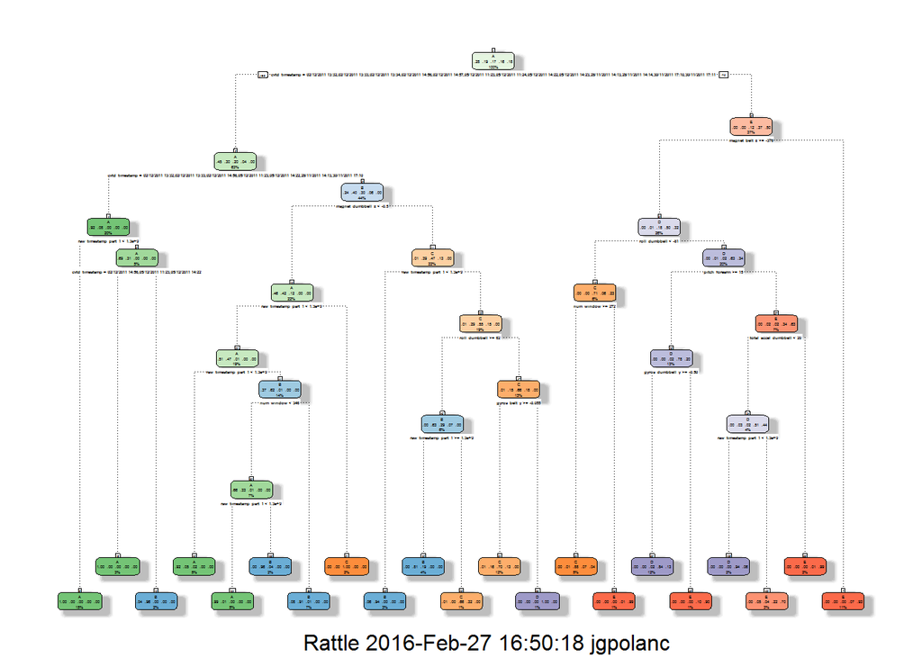

```r
fancyRpartPlot(Fit1)
```

Predicting:

```r
predict1 <- predict(Fit1, test_dat, type = "class")
```

Using confusion Matrix to test results:

```r
confusionMatrix(predict1, test_dat$classe)
```

```
## Confusion Matrix and Statistics
##
##           Reference
## Prediction    A    B    C    D    E
##          A 2161   28    5    3    0
##          B   58 1301   82    0    0
##          C   13  180 1239  194    6
##          D    0    1   27  982  154
##          E    0    8   15  107 1282
##
## Overall Statistics
##
##                Accuracy : 0.8877
##                  95% CI : (0.8805, 0.8946)
##     No Information Rate : 0.2845
##     P-Value [Acc > NIR] : < 2.2e-16
##
##                   Kappa : 0.8581
##  Mcnemar's Test P-Value : NA
##
## Statistics by Class:
##
##                      Class: A Class: B Class: C Class: D Class: E
## Sensitivity            0.9682   0.8570   0.9057   0.7636   0.8890
## Specificity            0.9936   0.9779   0.9393   0.9723   0.9797
## Pos Pred Value         0.9836   0.9028   0.7592   0.8436   0.9079
## Neg Pred Value         0.9874   0.9661   0.9792   0.9545   0.9751
## Prevalence             0.2845   0.1935   0.1744   0.1639   0.1838
## Detection Rate         0.2754   0.1658   0.1579   0.1252   0.1634
## Detection Prevalence   0.2800   0.1837   0.2080   0.1484   0.1800
## Balanced Accuracy      0.9809   0.9175   0.9225   0.8679   0.9344
```

# Using ML algorithms for prediction: Random Forests

```r
Fit2 <- randomForest(classe ~. , data=final_train)
```

```r
  predict2 <- predict(Fit2, test_dat, type = "class")
```

Using confusion Matrix to test results:

```r
confusionMatrix(predict2, test_dat$classe)
```

```
## Confusion Matrix and Statistics
##
##           Reference
## Prediction    A    B    C    D    E
##          A 2232    1    0    0    0
##          B    0 1516    5    0    0
##          C    0    1 1360    7    0
##          D    0    0    3 1279    0
##          E    0    0    0    0 1442
##
## Overall Statistics
##
##                Accuracy : 0.9978
##                  95% CI : (0.9965, 0.9987)
##     No Information Rate : 0.2845
##     P-Value [Acc > NIR] : < 2.2e-16
##
##                   Kappa : 0.9973
##  Mcnemar's Test P-Value : NA
##
## Statistics by Class:
##
##                      Class: A Class: B Class: C Class: D Class: E
## Sensitivity            1.0000   0.9987   0.9942   0.9946   1.0000
## Specificity            0.9998   0.9992   0.9988   0.9995   1.0000
## Pos Pred Value         0.9996   0.9967   0.9942   0.9977   1.0000
## Neg Pred Value         1.0000   0.9997   0.9988   0.9989   1.0000
## Prevalence             0.2845   0.1935   0.1744   0.1639   0.1838
## Detection Rate         0.2845   0.1932   0.1733   0.1630   0.1838
## Detection Prevalence   0.2846   0.1939   0.1744   0.1634   0.1838
## Balanced Accuracy      0.9999   0.9989   0.9965   0.9970   1.0000
```

# Generating Output for quiz submission

```r
predict3 <- predict(Fit2, validation, type = "class")
```